# Analyse du choix de filière par défaut ou par passion

Est-ce que le choix de filière par passion ou par défaut a un impact sur le comportement académique d’un étudiant ?

Cêlestine

18/12/2023

# INTRODUCTION

**Le choix d’une filière universitaire est souvent un moment décisif dans la vie d’un étudiant, influençant non seulement leur parcours académique, mais aussi leurs perspectives professionnelles futures.**

**Cette étude vise à explorer si les étudiants qui choisissent leur filière par passion sont plus susceptibles de s’engager activement dans leur travail académique et d’adopter des comportements bénéfiques pour leur apprentissage.**

# ANALYSE ET RESULTATS

Dans le cadre de cette étude, l’effectif des étudiants ayant choisi leur filière par passion, catégorisé comme “**Réorientation**” et “**Premier Choix**”, représente une majorité significative, indiquant une tendance à poursuivre des études alignées sur leurs intérêts et aspirations.

En contraste, les catégories “**Choix Intermédiaire**” et “**Dernier Choix**” reflètent les parcours de ceux qui, peut-être par circonstances ou compromis, se retrouvent dans des filières moins alignées avec leurs passions initiales.

| Votre licence est… | Effectifs |
| --- | --- |
| **Un choix par passion** |  |
| Réorientation | 43 |
| Premier Choix | 93 |
| **Un choix par défaut** |  |
| Choix Intermediaire | 54 |
| Dernier Choix | 18 |
| Total | 208 |

## Année d’étude

Les étudiants semblent moins enclins à poursuivre sur la durée un cursus sélectionné par défaut, privilégiant une réorientation vers des domaines d’étude qui reflètent mieux leurs véritables intérêts et aspirations.

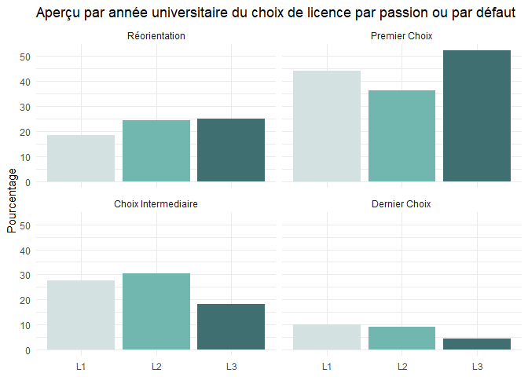

## Spécialités au baccalauréat

*Pour cette partie nous nous concentrons uniquement sur les étudiants en licence d’économie, qui représentent 80.8% des répondants pour une simplicité d’analyse.*

Les **étudiants avec un intérêt préalable en mathématiques ou en sciences économiques et sociales sont plus enclins à choisir délibérément la filière économie.**

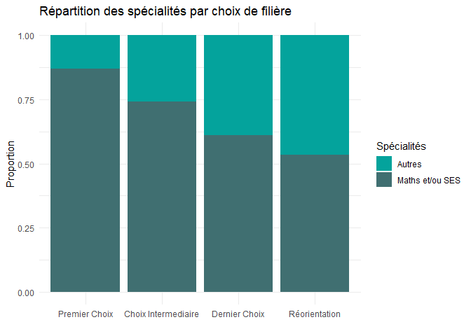

## Temps de travail personnel

À l’inverse, les étudiants pour qui la filière était leur dernier choix consacrent, en moyenne, moins de temps au travail personnel. Ceci peut indiquer un manque d’intérêt ou d’engagement envers la filière choisie.

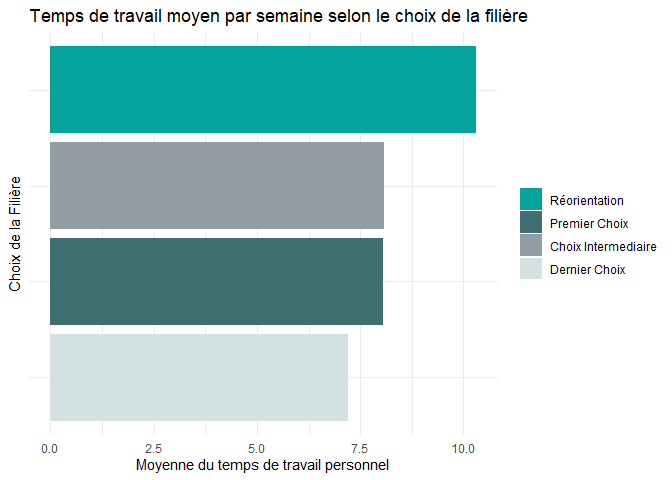

## Connaissance notion de cours

Les étudiants qui ont une préférence claire pour leur domaine d’étude, manifestée par un choix délibéré comme premier choix ou une réorientation déterminée, tendent à avoir une meilleure performance dans les questions académiques liées. Cela peut être dû à une motivation plus forte ou à un engagement plus profond dans leur domaine d’étude.

Taux de bonne réponse aux questions d’économie et de finance par choix de filière

|  | Réorientation | Premier Choix | Choix Intermediaire | Dernier Choix |
| --- | --- | --- | --- | --- |
| Taux de bonne réponse question d’économie | 70% | 76% | 70% | 61% |
| Taux de bonne réponse question de finance | 81% | 73% | 59% | 56% |

Question d’économie : Qui a inventé l’expression ‘’la main invisible’’ ? Adam Smith  
Question de finance : Quel terme désigne la répartition temporelle d’une charge financière pour remplacer un bien ou un équipement ? Amortissement

## Temps de trajet

Les étudiants dont la filière était leur premier choix ont tendance à avoir un temps de trajet plus court. Cela pourrait s’expliquer par le fait qu’ils ont délibérément choisi cette licence car elle se situe dans une faculté proche de leur domicile, ou qu’ils ont fait un effort pour réduire le temps de déplacement afin de maximiser le temps disponible pour étudier.

À l’inverse, ceux en réorientation ou qui ont choisi leur filière par défaut tendent à avoir un temps de trajet plus long, ce qui pourrait être expliqué par le fait qu’ils n’ont pas initialement prévu de faire cette licence et n’ont donc pas choisi leur logement en conséquence.

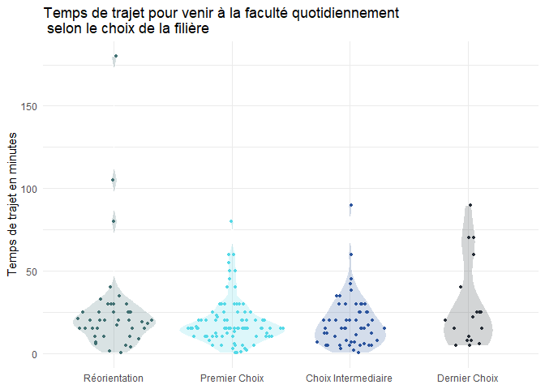

# CONCLUSION

**Les choix des étudiants relatifs à leur parcours universitaire ne sont pas anodins, ils reflètent et influencent à la fois leur niveau d’engagement et leur réussite académique.**

**Cette étude souligne l’importance pour les institutions d’accompagner les étudiants dans la découverte et la poursuite de leurs passions, tout en offrant un soutien adapté à ceux qui se trouvent dans des filières moins alignées avec leurs aspirations initiales, afin d’optimiser leur potentiel de réussite et de satisfaction académique.**

**Toutefois, il est important de reconnaître les limites de cette étude. Notre échantillon pourrait ne pas refléter la diversité complète de la population étudiante, et les résultats pourraient varier dans un contexte différent ou avec un échantillon plus large.**